# Peer Assessment 1

The following document is my answer for *Peer Assessment 1* during the course *Reproducible Research*.

## Loading and preprocessing the data

As a first step let us load a dataset dedicated for this assessment and look for some details of it.

```r
activity <- read.csv("/Volumes/Obraz dysku/2015.02 Coursera/AS1/activity.csv")
activity$dateD <- as.Date(as.character(activity$date), "%Y-%m-%d")
summary(activity)
```

```
##      steps                date          interval          dateD
##  Min.   :  0.00   2012-10-01:  288   Min.   :   0.0   Min.   :2012-10-01
##  1st Qu.:  0.00   2012-10-02:  288   1st Qu.: 588.8   1st Qu.:2012-10-16
##  Median :  0.00   2012-10-03:  288   Median :1177.5   Median :2012-10-31
##  Mean   : 37.38   2012-10-04:  288   Mean   :1177.5   Mean   :2012-10-31
##  3rd Qu.: 12.00   2012-10-05:  288   3rd Qu.:1766.2   3rd Qu.:2012-11-15
##  Max.   :806.00   2012-10-06:  288   Max.   :2355.0   Max.   :2012-11-30
##  NA's   :2304     (Other)   :15840
```

```r
str(activity)
```

```
## 'data.frame':    17568 obs. of  4 variables:
##  $ steps   : int  NA NA NA NA NA NA NA NA NA NA ...
##  $ date    : Factor w/ 61 levels "2012-10-01","2012-10-02",..: 1 1 1 1 1 1 1 1 1 1 ...
##  $ interval: int  0 5 10 15 20 25 30 35 40 45 ...
##  $ dateD   : Date, format: "2012-10-01" "2012-10-01" ...
```

## What is mean total number of steps taken per day?

### Calculate the total number of steps taken per day

I can use the fact that now in my dataset dates are stored as factors, so the total number of steps taken per each day is:

```r
StepsPerDay <- sapply(X = split(x = activity$steps, f = activity$date),
                      FUN = function(x) sum(x, na.rm = TRUE))
print(StepsPerDay)
```

```
## 2012-10-01 2012-10-02 2012-10-03 2012-10-04 2012-10-05 2012-10-06
##          0        126      11352      12116      13294      15420
## 2012-10-07 2012-10-08 2012-10-09 2012-10-10 2012-10-11 2012-10-12
##      11015          0      12811       9900      10304      17382
## 2012-10-13 2012-10-14 2012-10-15 2012-10-16 2012-10-17 2012-10-18
##      12426      15098      10139      15084      13452      10056
## 2012-10-19 2012-10-20 2012-10-21 2012-10-22 2012-10-23 2012-10-24
##      11829      10395       8821      13460       8918       8355
## 2012-10-25 2012-10-26 2012-10-27 2012-10-28 2012-10-29 2012-10-30
##       2492       6778      10119      11458       5018       9819
## 2012-10-31 2012-11-01 2012-11-02 2012-11-03 2012-11-04 2012-11-05
##      15414          0      10600      10571          0      10439
## 2012-11-06 2012-11-07 2012-11-08 2012-11-09 2012-11-10 2012-11-11
##       8334      12883       3219          0          0      12608
## 2012-11-12 2012-11-13 2012-11-14 2012-11-15 2012-11-16 2012-11-17
##      10765       7336          0         41       5441      14339
## 2012-11-18 2012-11-19 2012-11-20 2012-11-21 2012-11-22 2012-11-23
##      15110       8841       4472      12787      20427      21194
## 2012-11-24 2012-11-25 2012-11-26 2012-11-27 2012-11-28 2012-11-29
##      14478      11834      11162      13646      10183       7047
## 2012-11-30
##          0
```

### A histogram of the total number of steps taken each day

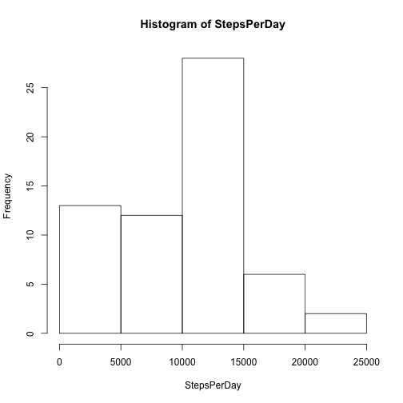

```r
hist(StepsPerDay)
```

### The mean and median of the total number of steps taken per day

The mean value of the total number of steps taken per day is:

```r
mean(StepsPerDay)
```

```
## [1] 9354.23
```

The median value of the total number of steps taken per day is:

```r
median(StepsPerDay)
```

```
## [1] 10395
```

## What is the average daily activity pattern?

A time series plot of the 5-minute interval (x-axis) and the average number of steps taken, averaged across all days (y-axis)

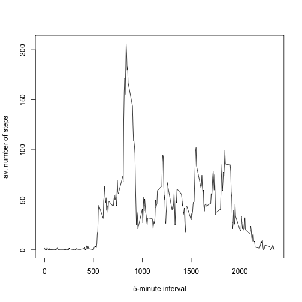

```r
x <- sapply(X = split(x = activity$steps, f = as.factor(activity$interval)),
            FUN = function(x) mean(x, na.rm = TRUE))
plot(x = as.numeric(names(x)), y = x, type = "l", xlab = "5-minute interval", ylab = "av. number of steps")
```

The 5-minute interval, which on average across all the days in the dataset, contains the maximum number of steps has a number

```r
names(x)[x==max(x)]
```

```
## [1] "835"
```

## Imputing missing values

The total number of missing values in the dataset is

```r
sum(!complete.cases(activity))
```

```
## [1] 2304
```

Imputing missing values I will use a mean value of steps for the 5-minute interval over all days.

```r
activityImp <- activity
activityImp$steps[is.na(activityImp$steps)] <- x[as.character(activityImp$interval[is.na(activityImp$steps)])]
summary(activityImp$steps)
```

```
##    Min. 1st Qu.  Median    Mean 3rd Qu.    Max.
##    0.00    0.00    0.00   37.38   27.00  806.00
```

We make now a histogram of the total number of steps taken each day and we calculate and report the mean and median total number of steps taken per day:

```r
StepsPerDayImp <- sapply(X = split(x = activityImp$steps, f = activityImp$date),
                      FUN = function(x) sum(x, na.rm = TRUE))
mean(StepsPerDayImp)
```

```
## [1] 10766.19
```

```r
median(StepsPerDayImp)
```

```
## [1] 10766.19
```

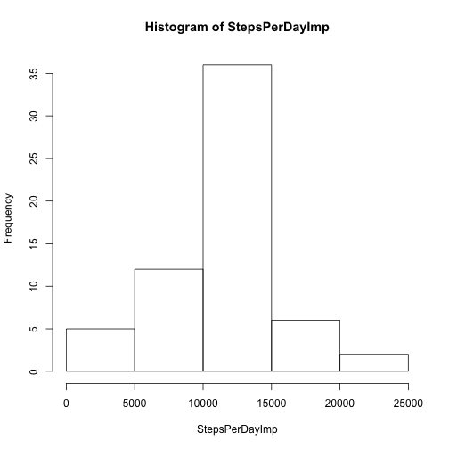

```r
hist(StepsPerDayImp)
```

## Are there differences in activity patterns between weekdays and weekends?

First we create a new factor variable in the dataset with two levels: **weekday** and **weekend**, indicating whether a given date is a weekday or weekend day (*I used a polish version of R; “sobota” = Saturday, “niedziela” = Sunday*).

```r
activity$dayF <- weekdays(activity$dateD)
activity$dayF[activity$dayF=="sobota" | activity$dayF=="niedziela"] <- "weekend"
activity$dayF[activity$dayF!="weekend"] <- "weekday"
summary(as.factor(activity$dayF))
```

```
## weekday weekend
##   12960    4608
```

Make a panel plot containing a time series plot (i.e. type = “l”) of the 5-minute interval (x-axis) and the average number of steps taken, averaged across all weekday days or weekend days (y-axis). See the README file in the GitHub repository to see an example of what this plot should look like using simulated data.

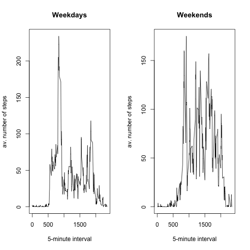

```r
activityWD <- activity[activity$dayF == "weekday",]
xWD <- sapply(X = split(x = activityWD$steps, f = as.factor(activityWD$interval)),
            FUN = function(x) mean(x, na.rm = TRUE))

activityWE <- activity[activity$dayF == "weekend",]
xWE <- sapply(X = split(x = activityWE$steps, f = as.factor(activityWE$interval)),
            FUN = function(x) mean(x, na.rm = TRUE))
par(mfcol = c(1, 2))
plot(x = as.numeric(names(xWD)), y = xWD, type = "l", main = "Weekdays",
     xlab = "5-minute interval", ylab = "av. number of steps")
plot(x = as.numeric(names(xWE)), y = xWE, type = "l", main = "Weekends",
     xlab = "5-minute interval", ylab = "av. number of steps")
```